# Introduction to Data Visualization with GGPlot

### Changing the Color

Start by changing the color of the histogram shading. Use the `fill = "color"` option to shade the histogram bars red. Where would you need to put this option to get it to apply to the histogram bars?

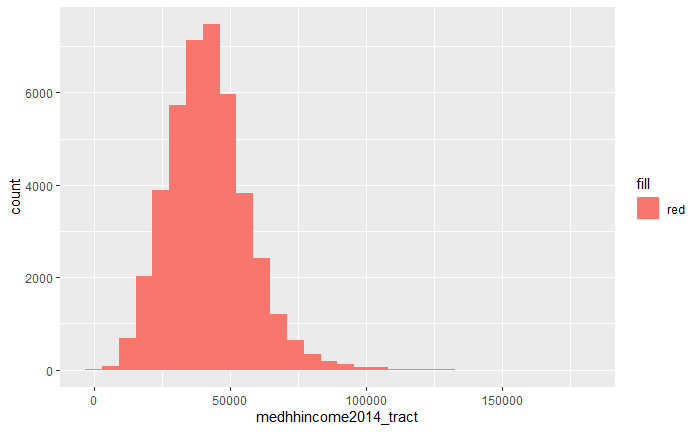

### Changing geometry-specific options

Try manually modifying the width of the histogram bins (right now it is split into 30 equally sized bars). Remember that binwidth is based on the values of the data (in this case, for instance, a binwidth of 2500 would be $2,500):

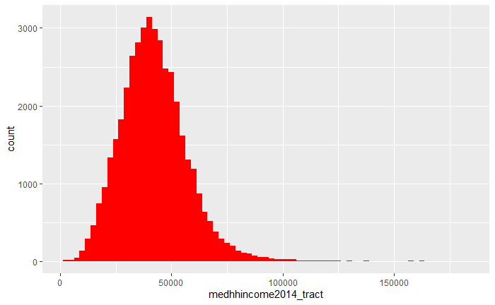

### Modifying Labels

Now’s a good time for us to polish our labels. `labs()` allows us to specify elements of the plot labels.

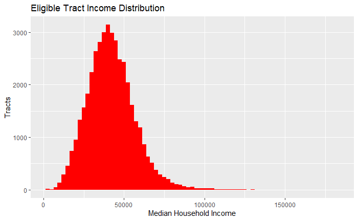

### Applying a Theme

Now let’s try applying a theme. As a reminder, themes allow us to change collections of formatting options all at once (we can also change any of these features manually). Try out a few themes to see which one you like (for example, the plot below applied theme_minimal()):

- theme_dark()
- theme_minimal()
- theme_classic()
- theme_void()
- Check out the [this list](https://yutannihilation.github.io/allYourFigureAreBelongToUs/) for even more GGPlot theme choices contained within other R packages

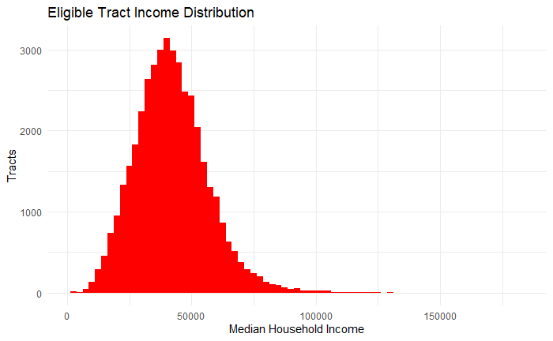

### Multiple Series

Rather than manually specifying the color of the plot, we could ask ggplot to create multiple series based upon our data. Let’s use the Designated variable to create separate series for our designated or not designated tracts:

```
Ignoring unknown parameters: bindwidth
```

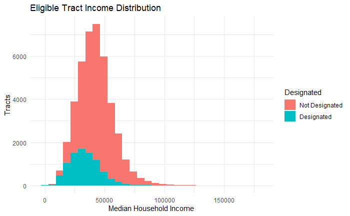

```r
ozs %>% ggplot(aes(x = medhhincome2014_tract, fill = Designated)) +
  geom_histogram(bindwidth = 2500)+
  labs(title = "Eligible Tract Income Distribution", x = "Median Household Income", y = "Tracts")+
  theme_minimal()
```

Now we can see some of the differences in the distribution of tract incomes by whether the tract was designated an Opportunity Zone or not. Why are the values for the Designated series so much shorter than that for the not designated tracts?

### Faceting

Recall that faceting is one of our higher level grammatical options for plots. Facets create multiple plots from subsets of the data. Let’s try faceting by state:

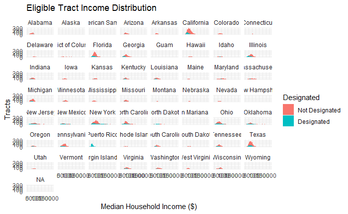

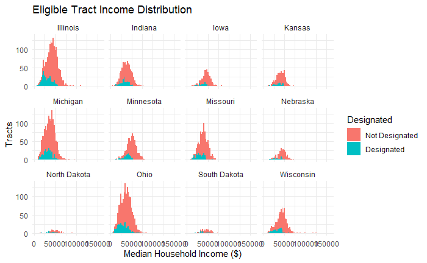

This is definitely more legible, but some states are hard to see because the number of tracts within each bin is very small compared to others (compare North Dakota to Ohio, for instance). By default, the scales in our facets are fixed based upon the minimum and maximum in the dataset. In our facet command, add the option `scales = "free"` and see what happens.

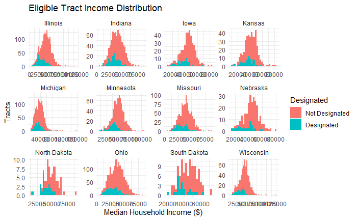

You should now see the facet scales change to reflect the minimums and maximums across each state’s distribution of values.

### Your turn

Try experimenting with some other 1-variable plots such as:

- geom_boxlot()
- geom_dotplot()
- geom_bar()
- geom_density()

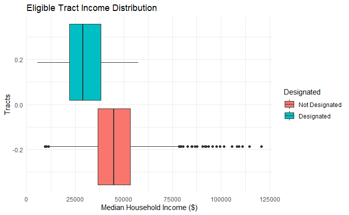

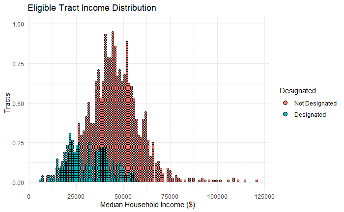

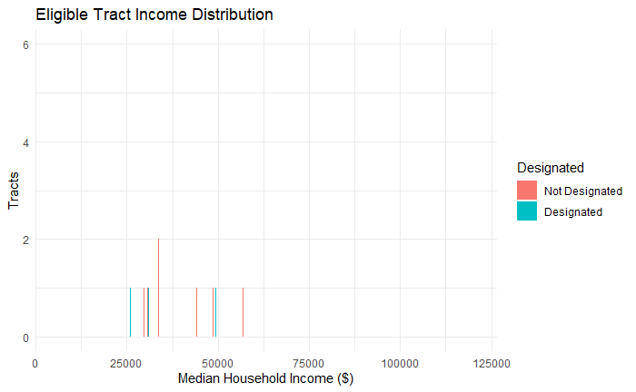

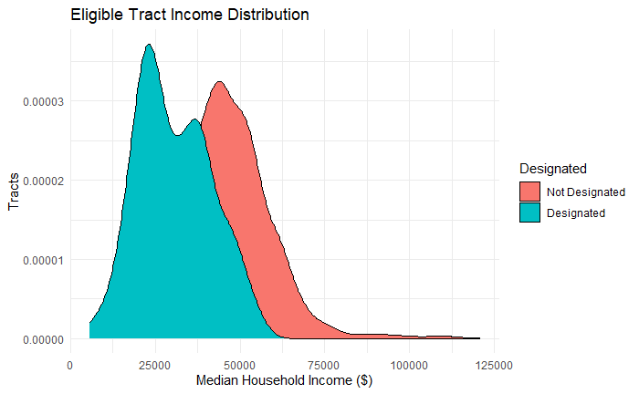

## Visualizing Two Dimensions

Now that you’re getting the hang of creating your own plots, let’s explore how to create a plot with two dimensions.

Let’s start off with a scatter plot. A scatter point represents data in two dimensions by marking a dot at the corresponding values along the x and y axis for each observation. Make a scatterplot `geom_point()` that visualizes the relationship between median household income (medhhincome2014_tract) and the proportion of the population with a Bachelor’s degree or higher (BAorhigher):

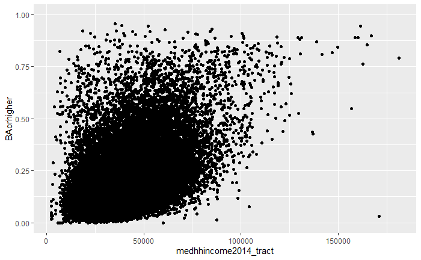

Now visualize the plot using different colors based upon whether the tract is designated as an Opportunity Zone or not:

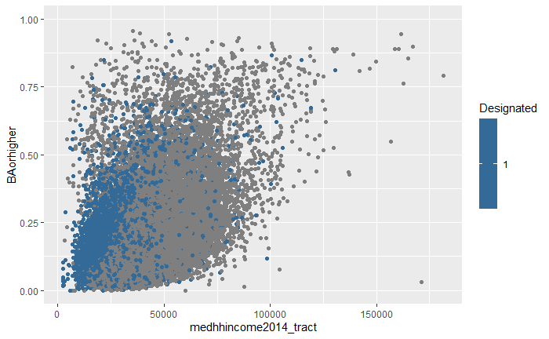

We have a lot of *overplotting* going on here with the points lying on top of each other so that it’s hard to see whether there are specific trends in the data. Let’s change the size and transparency for our points by adding in the options `alpha=.2` and `size = .5`

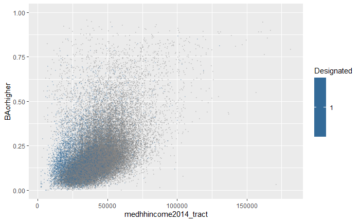

That helps some, but it’s still hard to tell what’s going on here.

### Add a Statistic

Let’s fit a line to the data to see what’s going on a little bit better. This allows us to utilize a statistic, in this case, `stat_smooth()`. Let’s fit a linear model (line of best fit) to our data by specifying method = “lm” (e.g. stat_smooth(method=“lm”):

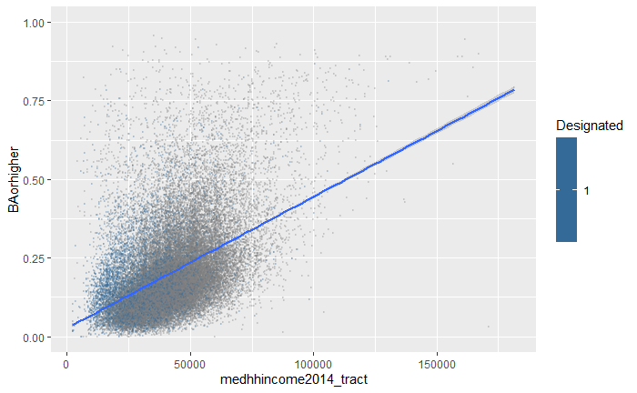

Based upon what you see here, how would you describe the relationship between income and higher education in designated versus undesignated eligible census tracts?

### Try some formatting

Now explore some options for cleaning up this plot. Apply themes and labels to make it look nicer. Google about the use of scales so that you can format the x axis in dollars and the y axis in percent.

[figure not shown]

# Extend your work

At the end of the last lab, you were asked to explore questions related to the following:

1. The racial composition and characteristics of designated and not-designated tracts
2. Differences in poverty rate for designated Opportunity Zones in metropolitan, micropolitan, and non-CBSA areas.
3. The age dependence ratio for designated and non-designated tracts
4. Average poverty and income for tracts based upon their level of investment flows

Let’s think about how we could explore these questions using some of our new-found data visualization strategies.

1. Make a series of kernel density plots (see Healy 4.6 for reference) that visualize differences in the racial compositions of census tracts. Try experimenting with the default and proportional density options for your y axis:

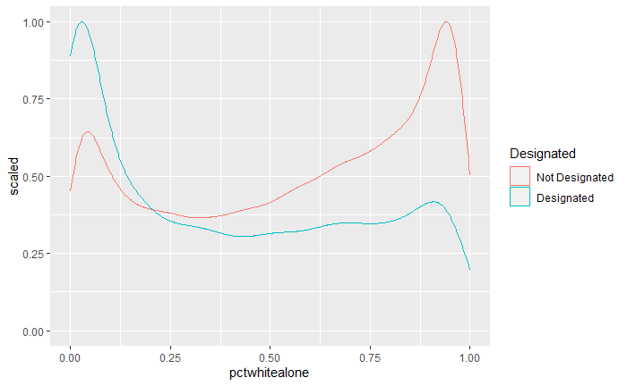

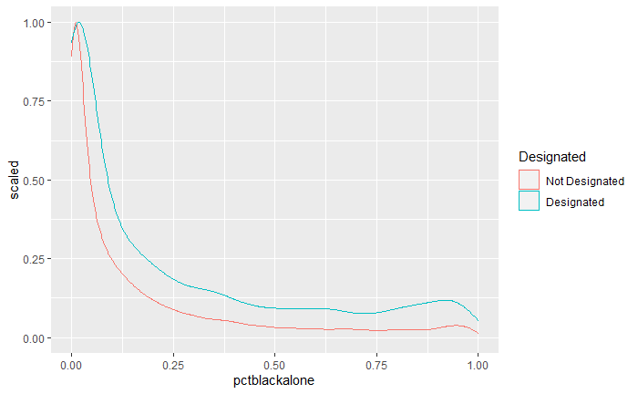

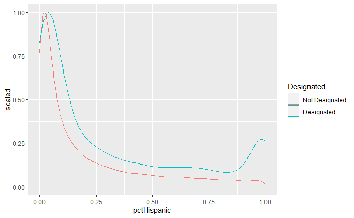

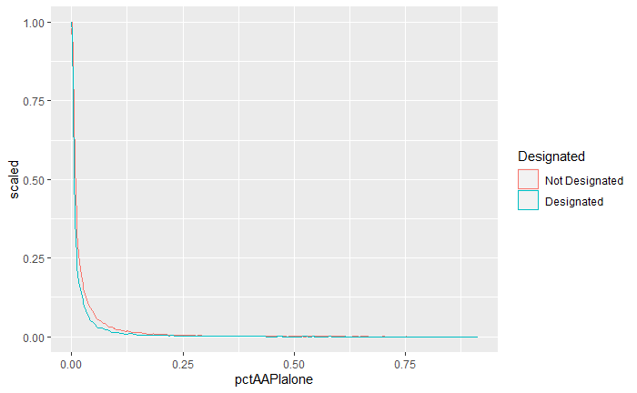

What insights can you glean about the racial composition of designated and non-designated tracts?

2. Next, let’s look at the differences in poverty rate for Designated and not-Designated tracts. Use faceting to make a histogram series that shows differences in the distribution of poverty rates designated and not designated tracts using metropolitan status as a faceting variable. I’ve included some code to create a new variable called “Metro_Type” that includes whether a tract is Metropolitan, Micropolitan, or Non CBSA (neither Metropolitan or Micropolitan) - you can build upon this to create your visualization.

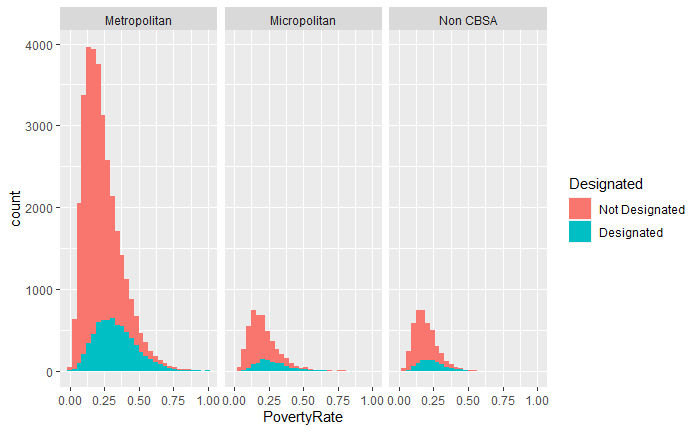

3. Create a boxplot that visualizes the distribution of age dependence ratios for designated and non-designated census tracts for midwestern states (). **Reminder**: The age dependence ratio is the proportion of the population under 18 or over 64 compared to the population between 18 and 64. In our dataset, we have the proportion under 18 (pctunder18) and the proportion over 64 (pctover64)

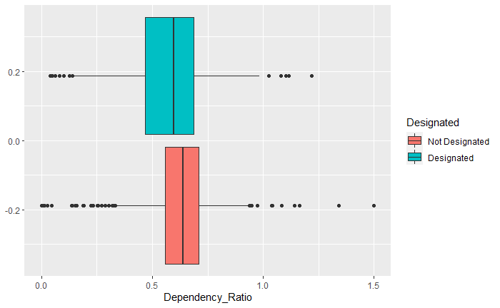

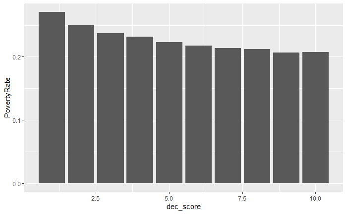

In the Healy text, you learned about some of the features of geom_bar (section 4.5). Let’s use a related geometry, geom_col() to represent our summarized average poverty rates by the investment score (Investment Score on X axis, Poverty Rate on Y axis):

```r
# Your Work Here
ozs %>% group_by(dec_score) %>% summarise(PovertyRate = mean(PovertyRate, na.rm = TRUE)) %>% ggplot(aes(x = dec_score, y = PovertyRate)) + geom_col()
```

Now think about what some things are that we might want to do to clean up this plot: - Remove the column reporting NA values for dec_score - Get ggplot to treat the x axis as categorical (rather than continuous) - Add descriptive labels - Remove excess shading by selecting an appropriate theme - Change the color of the fill on the bars to a different color

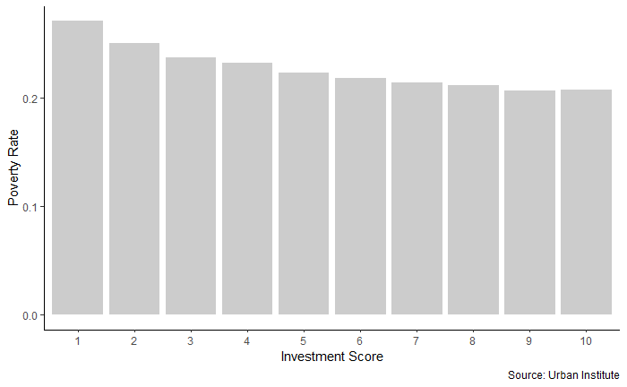

Now let’s try visualizing the same data using a different strategy - kernel density plots. As a reminder, kernel density plots are like a continuous histogram (with smoothed curves instead of bins for data). Make a kernel density plot for the distribution of poverty rate, with different series defined by each investment score category.

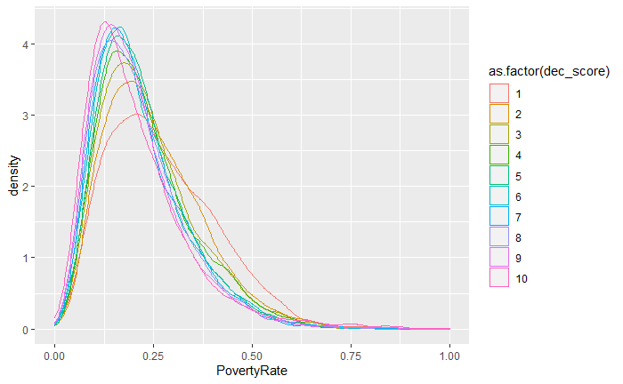

There’s some useful information here- clearly as investment potential is related to the poverty rate. How could we simplify this plot to help with legibility? One strategy would be to classify the investment scores into “Low”, “Medium”, and “High” categories. Here’s some code that does just that. Build a kernel density plot plot using the revised categories contained in the new variable, “Investment”:

[figure not shown]

Congratulations! You are now immersed in GGplot - it will take some time to get used to the logic, but as you do become more familiar, you will be able to create many different types of data visualizations with relative ease. You will also know your data a lot better through the process of visualizing it.

For some inspiration at some options, take a look [here](https://www.r-graph-gallery.com/ggplot2-package.html).